# kramers Practice

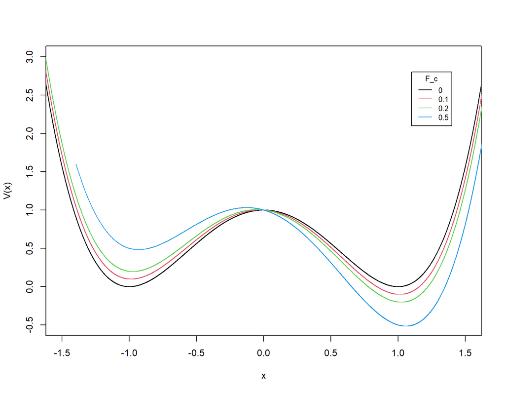

```r
V <- function(x, F_c){
  return (1*(x**2 - 1)**2 - F_c * x)
}

plot(1, type='n', xlab='x', ylab='V(x)', xlim=c(-1.5,1.5), ylim=c(-0.5,3))
lines(x=x[1,], y=V(x[1,],0), col=1)
lines(x=x_f1[1,], y=V(x_f1[1,],0.1), col=2)
lines(x=x_f2[1,], y=V(x_f2[1,],0.2), col=3)
lines(x=x_f3[1,], y=V(x_f3[1,],0.5), col=4)
legend(1.1,2.8,legend=c(0,0.1,0.2,0.5), lty=1, col=c(1,2,3,4),cex=0.8, title='F_c')
```

## 4. Plot the distribution of positions x at the different forces

Plot of the first experiment:

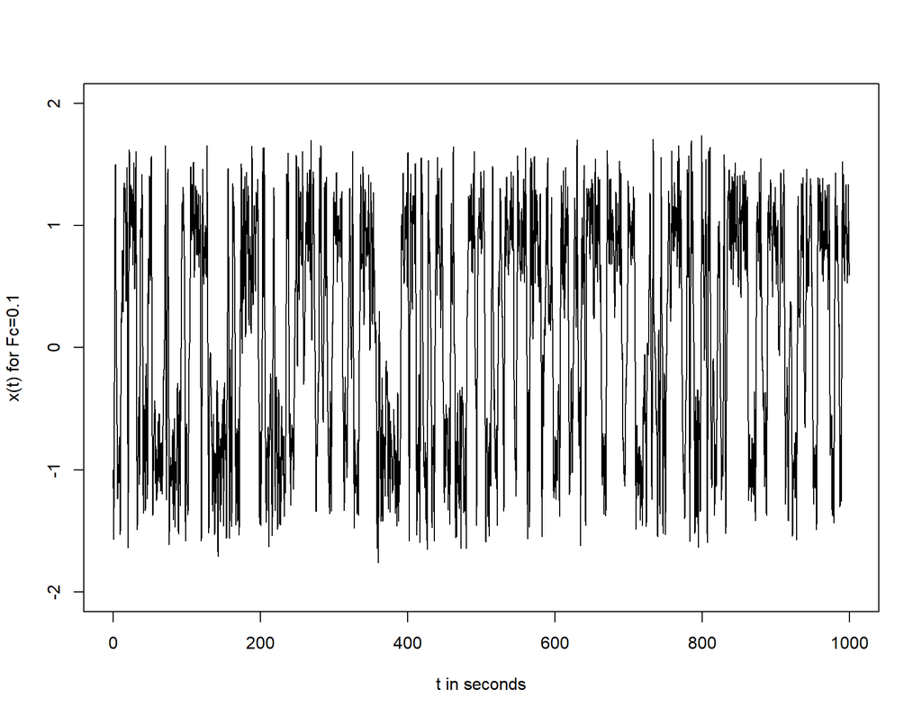

```r
plot(1, type='n', xlab='t in seconds', ylab='x(t) for Fc=0.1', xlim=c(0,1000), ylim=c(-2,2), lty=1, lwd=1)
lines(x=seq(delta_t,t_finish,by=delta_t), y=x_f1[1,], col=1)
```

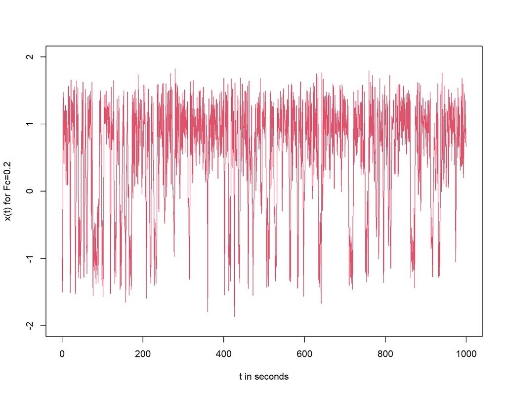

```r
plot(1, type='n', xlab='t in seconds', ylab='x(t) for Fc=0.2', xlim=c(0,1000), ylim=c(-2,2), lty=1, lwd=1)
lines(x=seq(delta_t,t_finish,by=delta_t), y=x_f2[1,], col=2)
```

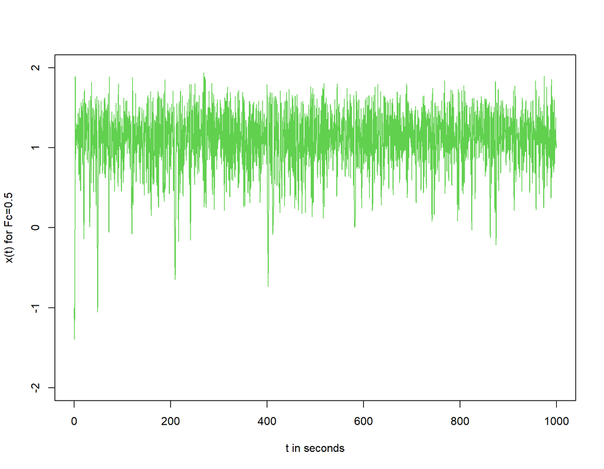

```r
plot(1, type='n', xlab='t in seconds', ylab='x(t) for Fc=0.5', xlim=c(0,1000), ylim=c(-2,2), lty=1, lwd=1)
lines(x=seq(delta_t,t_finish,by=delta_t), y=x_f3[1,], col=3)
```

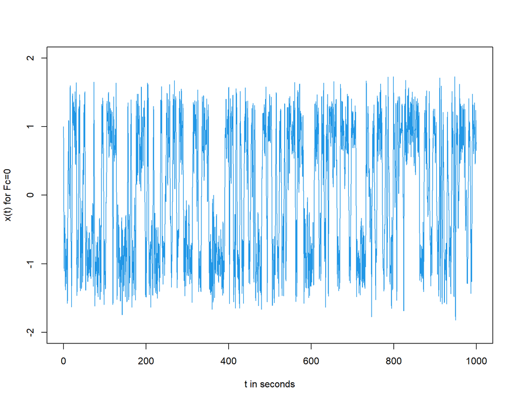

```r
plot(1, type='n', xlab='t in seconds', ylab='x(t) for Fc=0', xlim=c(0,1000), ylim=c(-2,2), lty=1, lwd=1)
lines(x=seq(delta_t,t_finish,by=delta_t), y=x[1,], col=4)
```

Histograms:

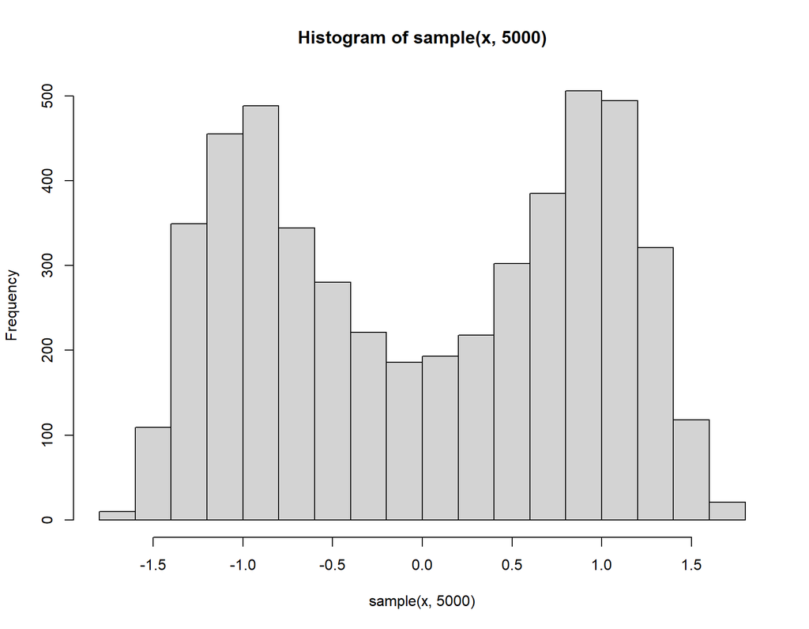

```r
hist(sample(x, 5000))
```

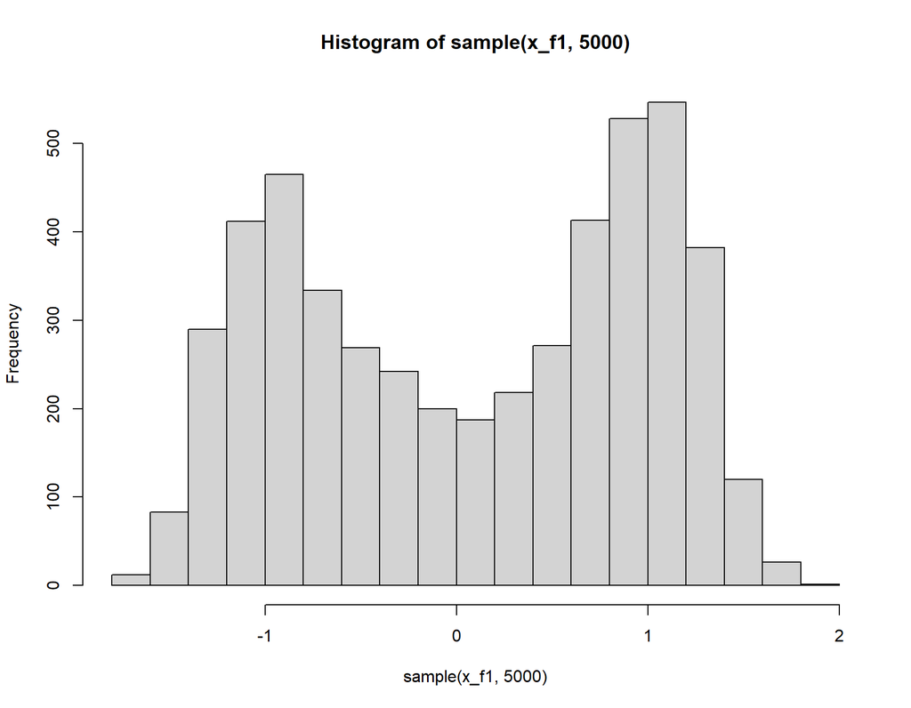

```r
hist(sample(x_f1, 5000))
```

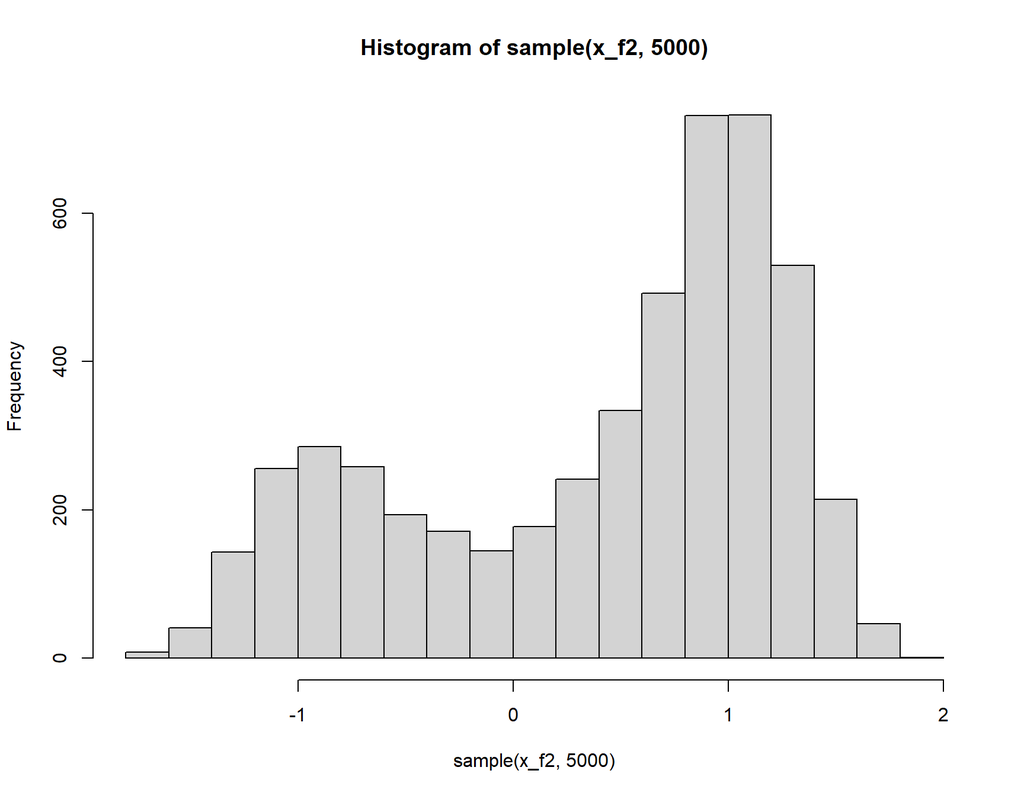

```r
hist(sample(x_f2, 5000))
```

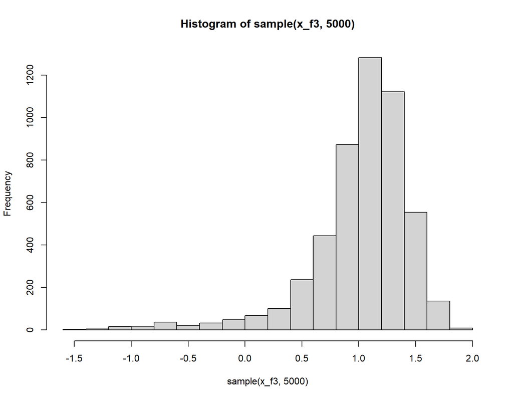

```r
hist(sample(x_f3, 5000))
```

## 5. Calculate the mean residence time of the R state as a function of the force tR(FC)

```r
t <- 0
res_t_max1 <- NULL

for (i in 2:N_steps) {
  if (x_f1[1, i] > 0) {
    t <- t + 1
  } else {
    t <- 0
  }
  res_t_max1 <- cbind(res_t_max1, t * 0.01)
}

res_t_max2 <- NULL

for (i in 2:N_steps) {
  if (x_f2[1, i] > 0) {
    t <- t + 1
  } else {
    t <- 0
  }
  res_t_max2 <- cbind(res_t_max2, t * 0.01)
}

res_t_max3 <- NULL

for (i in 2:N_steps) {
  if (x_f3[1, i] > 0) {
    t <- t + 1
  } else {
    t <- 0
  }
  res_t_max3 <- cbind(res_t_max3, t * 0.01)
}
```

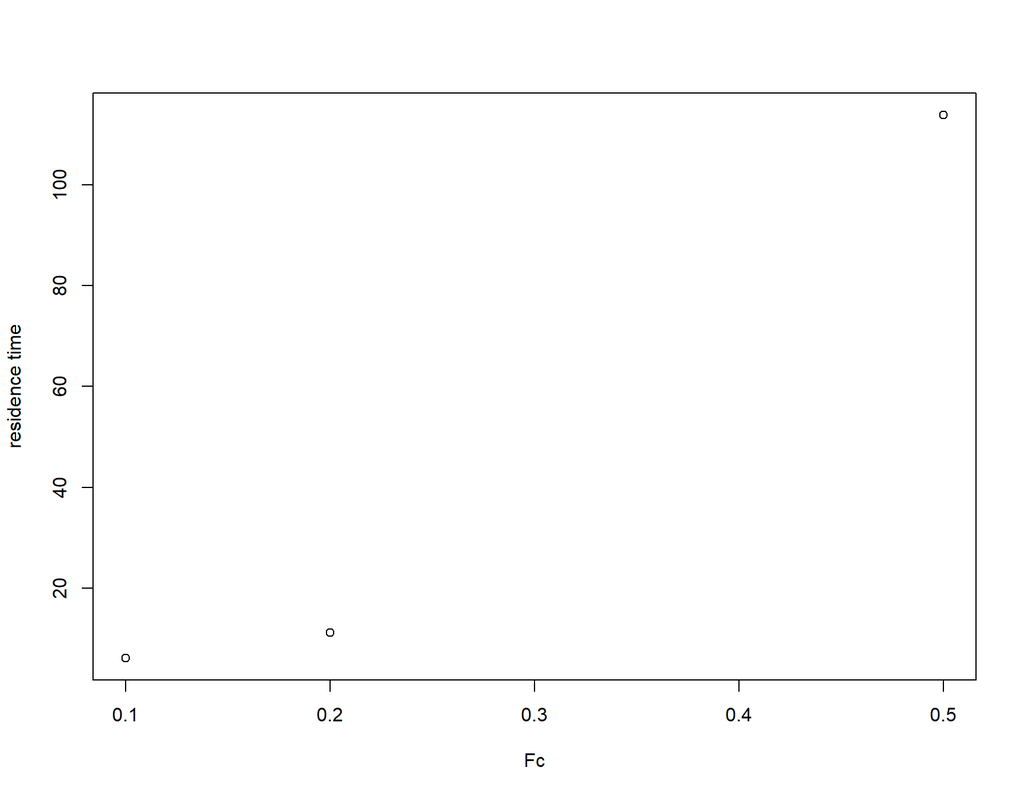

```r
plot(x=c(0.1,0.2,0.5), y=c(mean(res_t_max1[res_t_max1!=0]),mean(res_t_max2[res_t_max2!=0]), mean(res_t_max3[res_t_max3!=0])), xlab='Fc' , ylab='residence time')
```

## 6. Plot the probability to find the particle at the right hand side of the potential (nR/N) as a

function of the applied force F = [0.2, 2] – steps 0.2. Which kind of function does appear?

```r
potential <- function(x, B, F_c) {
  return(B * (((x^2) - 1)^2) - F_c * x)
}

force_potential <- function(x, B, F_c) {
  return(-4 * B * x * (x^2 - 1) + F_c)
}

gamma_vec <- c(0.1, 1, 10.0)
B_vec <- c(0.1, 1, 1.5)
F_c <- seq(0.2,2,by=0.2)
mass <- 1.0
kbT <- 1.0

delta_t <- 0.01
t_finish <- 1000

N_steps <- as.integer(t_finish / delta_t)

index_gamma <- 2
index_B <- 2

x_f <- matrix(0, nrow = length(F_c), ncol = N_steps)
v_f <- matrix(0, nrow = length(F_c), ncol = N_steps)

for (i in 1:length(F_c)) {

  B_gj <- 1 / (1 + gamma_vec[index_gamma] * delta_t / (2 * mass))
  A_gj <- B_gj * (1 - gamma_vec[index_gamma] * delta_t / (2 * mass))
  stoch <- sqrt(2 * gamma_vec[index_gamma] * kbT * delta_t)

  v_f[i,1] <- runif(1) - 0.5
  x_f[i,1] <- sample(c(-1, 1), size = 1, replace = TRUE)

  for (index_step in 2:N_steps) {

    W <- stoch * rnorm(1)

    x_f[i, index_step] <- x_f[i, index_step - 1] + B_gj * delta_t * v_f[i, index_step - 1] + (B_gj * delta_t * delta_t / (2 * mass)) * force_potential(x_f[i, index_step - 1], B_vec[index_B], F_c[i]) + (B_gj * delta_t / (2 * mass)) * W

    v_f[i, index_step] <- A_gj * v_f[i, index_step - 1] + (delta_t / (2 * mass)) * (A_gj * force_potential(x_f[i, index_step - 1], B_vec[index_B], F_c[i]) + force_potential(x_f[i, index_step], B_vec[index_B], F_c[i])) + (B_gj / mass) * W
  }
}
```

```r
p_f <- c()
for (i in 1:length(F_c)){
 p_f[i]<-length(x_f[i,x_f[i,]>0])/length(x_f[i,])
}
```

```r
summary(lm(p_f~log(F_c)))
```

```
##
## Call:
## lm(formula = p_f ~ log(F_c))
##
## Residuals:
##       Min        1Q    Median        3Q       Max
## -0.053278 -0.030955  0.001729  0.029803  0.050564
##
## Coefficients:
##             Estimate Std. Error t value Pr(>|t|)
## (Intercept)  0.83184    0.01232  67.500 2.58e-12 ***
## log(F_c)     0.16288    0.01754   9.284 1.47e-05 ***
## ---
## Signif. codes:  0 '***' 0.001 '**' 0.01 '*' 0.05 '.' 0.1 ' ' 1
##
## Residual standard error: 0.03858 on 8 degrees of freedom
## Multiple R-squared:  0.9151, Adjusted R-squared:  0.9045
## F-statistic: 86.19 on 1 and 8 DF,  p-value: 1.474e-05
```

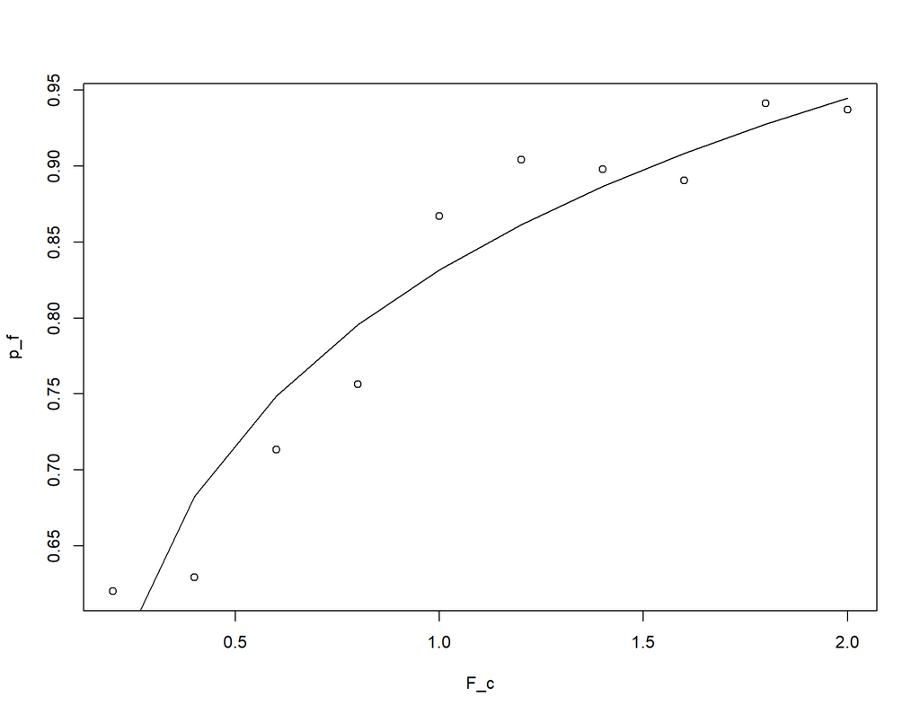

```r
a<-lm(p_f~log(F_c))$coefficients[1]
b<- lm(p_f~log(F_c))$coefficients[2]

plot(x=F_c, y=p_f)
lines(x=F_c, y=log(F_c)*b+a)
```

The result can be approached to a logarithmic function.

## 7. Estimate the position of the barrier ($x_M$) in the Bell Approximation.

$F(x) = −4Bx(x^2 −1) + F_C$ The x where force is maxima will be our estimated $x_M$:

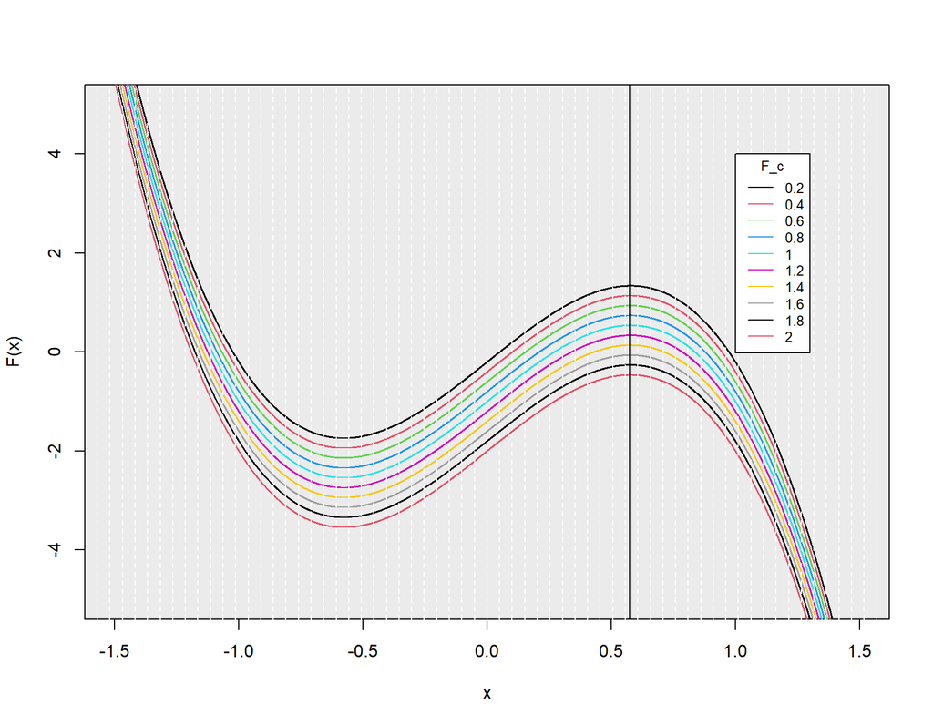

```r
Force <- function(x, F_c){
  return (-4*x*(x**2 - 1)- F_c)
}

plot(1, type='n', xlab='x', ylab='F(x)', xlim=c(-1.5,1.5), ylim=c(-5,5))
rect(par("usr")[1], par("usr")[3],par("usr")[2], par("usr")[4],col = "#ebebeb")
for (i in 1:length(F_c)){
lines(x=x_f[i,], y=Force(x=x_f[i,],F_c[i]), col=i)
}
grid(nx = 64, ny = NA, lty = 2, col = "white", lwd = 1)
legend(1,4,legend=seq(0.2,2,by=0.2), lty=1, col=seq(1,length(F_c)),cex=0.8, title='F_c')
abline(v=0.575)
```

The estimate pposition of $x_M$ is 0.575.